# Análisis Exploratorio de Datos (EDA)

EIY403 - Introducción al Análisis de Datos para Otras Carreras - Clase 2

Universidad Nacional de Costa Rica - Escuela de Informática y Computación

2025-08-12

## Objetivos de esta Sesión

Al finalizar esta actividad, usted será capaz de:

- Aplicar el proceso completo de EDA paso a paso con datos reales
- Evaluar la calidad de datos químicos de laboratorio
- Tomar decisiones inteligentes sobre limpieza de datos
- Clasificar y analizar diferentes tipos de variables
- Crear visualizaciones efectivas para datos químicos
- Interpretar medidas estadísticas en el contexto de química
- Implementar estructuras de control para automatizar análisis

**📚 Contexto del Dataset:** Trabajaremos con datos reales de experimentos de laboratorio de química, incluyendo mediciones de pH, concentraciones, temperaturas y características físico-químicas de diferentes tipos de soluciones.

# 1 Paso 1: Carga y Exploración Inicial de Datos

## 1.1 Carga del Dataset

```r
# Cargar el dataset de experimentos químicos
# NOTA: Ajustar la ruta según tu sistema
ruta_archivo <- "/Users/jordyab00/Downloads/dataset_quimica_eda.txt"

# Verificar que el archivo existe
if (file.exists(ruta_archivo)) {
    # Leer el archivo CSV
    datos_quimica <- read.csv(ruta_archivo, stringsAsFactors = FALSE)
    cat("Archivo cargado exitosamente\n")
    cat("Dimensiones:", nrow(datos_quimica), "filas x", ncol(datos_quimica), "columnas\n")
} else {
    cat("Error: No se encontró el archivo en la ruta especificada\n")
    cat("Ruta buscada:", ruta_archivo, "\n")
    cat("Verifica la ruta y ajusta según tu sistema\n")
}
```

```
#> Archivo cargado exitosamente
#> Dimensiones: 100 filas x 16 columnas
```

## 1.2 Inspección Inicial - ¿Qué tenemos?

```r
# Estructura del dataset
cat("=== ESTRUCTURA DEL DATASET ===\n")
```

```
#> === ESTRUCTURA DEL DATASET ===
```

```r
str(datos_quimica)
```

```
#> 'data.frame':    100 obs. of  16 variables:
#>  $ experimento_id          : chr  "E001" "E002" "E003" "E004" ...
#>  $ estudiante_id           : chr  "EST_001" "EST_002" "EST_003" "EST_004" ...
#>  $ laboratorio             : chr  "Lab_A" "Lab_A" "Lab_B" "Lab_C" ...
#>  $ tipo_solucion           : chr  "acido_base" "acido_base" "salina" "azucarada" ...
#>  $ fecha_experimento       : chr  "2025-03-10" "2025-03-10" "2025-03-10" "2025-03-10" ...
#>  $ ph                      : num  3.2 3.1 7 6.8 3 7.1 6.9 2.9 7.2 7 ...
#>  $ temperatura_C           : num  22.5 22.8 21.2 23.1 22.9 21.8 23.5 23.2 21.5 22.8 ...
#>  $ concentracion_sal_mg_L  : int  150 145 850 50 148 820 45 152 875 52 ...
#>  $ concentracion_azucar_g_L: int  0 0 0 125 0 0 130 0 0 120 ...
#>  $ volumen_muestra_mL      : int  100 100 250 200 100 250 200 100 250 200 ...
#>  $ masa_soluto_g           : num  2.5 2.4 8.5 25 2.6 8.2 26 2.7 8.8 24 ...
#>  $ densidad_g_mL           : num  1.02 1.02 1.04 1.06 1.02 ...
#>  $ tiempo_reaccion_min     : num  5.2 5.5 0 0 5.8 0 0 6.1 0 0 ...
#>  $ color                   : chr  "incoloro" "incoloro" "incoloro" "incoloro" ...
#>  $ estado_fisico           : chr  "liquido" "liquido" "liquido" "liquido" ...
#>  $ precipitado_formado     : chr  "no" "no" "no" "no" ...
```

```r
cat("\n=== PRIMERAS 6 FILAS ===\n")
```

```
#>
#> === PRIMERAS 6 FILAS ===
```

```r
head(datos_quimica)
```

|  | experimento_id | estudiante_id | laboratorio | tipo_solucion | fecha_experimento | ph | temperatura_C | concentracion_sal_mg_L | concentracion_azucar_g_L | volumen_muestra_mL | masa_soluto_g | densidad_g_mL | tiempo_reaccion_min | color | estado_fisico | precipitado_formado |
| --- | --- | --- | --- | --- | --- | --- | --- | --- | --- | --- | --- | --- | --- | --- | --- | --- |
| 1 | E001 | EST_001 | Lab_A | acido_base | 2025-03-10 | 3.2 | 22.5 | 150 | 0 | 100 | 2.5 | 1.020 | 5.2 | incoloro | liquido | no |
| 2 | E002 | EST_002 | Lab_A | acido_base | 2025-03-10 | 3.1 | 22.8 | 145 | 0 | 100 | 2.4 | 1.018 | 5.5 | incoloro | liquido | no |
| 3 | E003 | EST_003 | Lab_B | salina | 2025-03-10 | 7.0 | 21.2 | 850 | 0 | 250 | 8.5 | 1.045 | 0.0 | incoloro | liquido | no |
| 4 | E004 | EST_004 | Lab_C | azucarada | 2025-03-10 | 6.8 | 23.1 | 50 | 125 | 200 | 25.0 | 1.065 | 0.0 | incoloro | liquido | no |
| 5 | E005 | EST_005 | Lab_A | acido_base | 2025-03-11 | 3.0 | 22.9 | 148 | 0 | 100 | 2.6 | 1.021 | 5.8 | incoloro | liquido | no |
| 6 | E006 | EST_006 | Lab_B | salina | 2025-03-11 | 7.1 | 21.8 | 820 | 0 | 250 | 8.2 | 1.042 | 0.0 | incoloro | liquido | no |

```r
cat("\n=== ÚLTIMAS 6 FILAS ===\n")
```

```
#>
#> === ÚLTIMAS 6 FILAS ===
```

```r
tail(datos_quimica)
```

|  | experimento_id | estudiante_id | laboratorio | tipo_solucion | fecha_experimento | ph | temperatura_C | concentracion_sal_mg_L | concentracion_azucar_g_L | volumen_muestra_mL | masa_soluto_g | densidad_g_mL | tiempo_reaccion_min | color | estado_fisico | precipitado_formado |
| --- | --- | --- | --- | --- | --- | --- | --- | --- | --- | --- | --- | --- | --- | --- | --- | --- |
| 95 | E095 | EST_095 | Lab_A | cristalizacion | 2025-04-10 | 4.0 | 27.6 | 2185 | 0 | 50 | 9.3 | 1.128 | 42.2 | azul_oscuro | liquido | si |
| 96 | E096 | EST_096 | Lab_B | cristalizacion | 2025-04-10 | 4.2 | 26.8 | 2125 | 0 | 50 | 8.8 | 1.124 | 45.7 | azul | liquido | si |
| 97 | E097 | EST_097 | Lab_C | cristalizacion | 2025-04-10 | 4.1 | 27.2 | 2155 | 0 | 50 | 9.0 | 1.126 | 44.5 | azul_oscuro | liquido | si |
| 98 | E098 | EST_098 | Lab_A | indicadores | 2025-04-11 | 11.8 | 22.1 | 180 | 0 | 200 | 3.8 | 1.022 | 2.5 | rosa | liquido | no |
| 99 | E099 | EST_099 | Lab_B | cristalizacion | 2025-04-11 | 4.3 | 26.6 | 2145 | 0 | 50 | 8.9 | 1.125 | 45.1 | azul | liquido | si |
| 100 | E100 | EST_100 | Lab_C | indicadores | 2025-04-11 | NA | 22.5 | NA | 0 | 200 | 3.9 | NA | 2.8 | rosa_claro | liquido |  |

```r
cat("\n=== NOMBRES DE LAS VARIABLES ===\n")
```

```
#>
#> === NOMBRES DE LAS VARIABLES ===
```

```r
colnames(datos_quimica)
```

```
#>  [1] "experimento_id"           "estudiante_id"
#>  [3] "laboratorio"              "tipo_solucion"
#>  [5] "fecha_experimento"        "ph"
#>  [7] "temperatura_C"            "concentracion_sal_mg_L"
#>  [9] "concentracion_azucar_g_L" "volumen_muestra_mL"
#> [11] "masa_soluto_g"            "densidad_g_mL"
#> [13] "tiempo_reaccion_min"      "color"
#> [15] "estado_fisico"            "precipitado_formado"
```

## 1.3 Resumen Estadístico Inicial

```r
# Resumen estadístico básico
cat("=== RESUMEN ESTADÍSTICO INICIAL ===\n")
```

```
#> === RESUMEN ESTADÍSTICO INICIAL ===
```

```r
summary(datos_quimica)
```

```
#>  experimento_id     estudiante_id      laboratorio        tipo_solucion
#>  Length:100         Length:100         Length:100         Length:100
#>  Class :character   Class :character   Class :character   Class :character
#>  Mode  :character   Mode  :character   Mode  :character   Mode  :character
#>
#>
#>
#>
#>  fecha_experimento        ph         temperatura_C   concentracion_sal_mg_L
#>  Length:100         Min.   : 1.200   Min.   :21.20   Min.   :  45.0
#>  Class :character   1st Qu.: 4.225   1st Qu.:22.88   1st Qu.: 150.0
#>  Mode  :character   Median : 6.500   Median :23.60   Median : 325.0
#>                     Mean   : 5.909   Mean   :24.06   Mean   : 759.4
#>                     3rd Qu.: 7.000   3rd Qu.:25.02   3rd Qu.:1190.0
#>                     Max.   :11.800   Max.   :27.60   Max.   :2185.0
#>                     NA's   :2                        NA's   :1
#>  concentracion_azucar_g_L volumen_muestra_mL masa_soluto_g    densidad_g_mL
#>  Min.   :  0.00           Min.   : 50        Min.   : 2.400   Min.   :1.012
#>  1st Qu.:  0.00           1st Qu.:100        1st Qu.: 3.275   1st Qu.:1.021
#>  Median :  0.00           Median :150        Median : 8.800   Median :1.068
#>  Mean   : 20.87           Mean   :156        Mean   :10.631   Mean   :1.063
#>  3rd Qu.:  0.00           3rd Qu.:200        3rd Qu.:15.225   3rd Qu.:1.093
#>  Max.   :140.00           Max.   :300        Max.   :28.000   Max.   :1.128
#>                                                               NA's   :1
#>  tiempo_reaccion_min    color           estado_fisico      precipitado_formado
#>  Min.   : 0.00       Length:100         Length:100         Length:100
#>  1st Qu.: 0.00       Class :character   Class :character   Class :character
#>  Median : 3.90       Mode  :character   Mode  :character   Mode  :character
#>  Mean   :10.55
#>  3rd Qu.:10.30
#>  Max.   :48.80
#>
```

```r
# Información adicional sobre el dataset
cat("\n=== INFORMACIÓN ADICIONAL ===\n")
```

```
#>
#> === INFORMACIÓN ADICIONAL ===
```

```r
cat("Número total de observaciones:", nrow(datos_quimica), "\n")
```

```
#> Número total de observaciones: 100
```

```r
cat("Número de variables:", ncol(datos_quimica), "\n")
```

```
#> Número de variables: 16
```

```r
cat("Rango de fechas:", min(datos_quimica$fecha_experimento, na.rm = TRUE), "a",
    max(datos_quimica$fecha_experimento, na.rm = TRUE), "\n")
```

```
#> Rango de fechas: 2025-03-10 a 2025-04-11
```

```r
cat("Laboratorios incluidos:", paste(unique(datos_quimica$laboratorio), collapse = ", "), "\n")
```

```
#> Laboratorios incluidos: Lab_A, Lab_B, Lab_C
```

```r
cat("Tipos de solución:", paste(unique(datos_quimica$tipo_solucion), collapse = ", "), "\n")
```

```
#> Tipos de solución: acido_base, salina, azucarada, precipitacion, neutralizacion, concentracion, dilucion, cristalizacion, indicadores
```

# 2 Paso 2: Evaluación de Calidad de Datos

## 2.1 Análisis de Valores Faltantes

```r
# Detectar valores faltantes por columna
valores_faltantes <- colSums(is.na(datos_quimica))
porcentaje_faltantes <- round((valores_faltantes / nrow(datos_quimica)) * 100, 2)

# Crear tabla de valores faltantes
tabla_faltantes <- data.frame(
    Variable = names(valores_faltantes),
    Valores_Faltantes = valores_faltantes,
    Porcentaje = porcentaje_faltantes,
    Evaluacion = ifelse(porcentaje_faltantes == 0, "Completo",
                       ifelse(porcentaje_faltantes < 5, "Pocos faltantes",
                             ifelse(porcentaje_faltantes < 15, "Moderados faltantes",
                                   "Muchos faltantes")))
)

# Mostrar tabla
kable(tabla_faltantes,
      caption = "Análisis de Valores Faltantes por Variable",
      align = "lccc")
```

Análisis de Valores Faltantes por Variable

|  | Variable | Valores_Faltantes | Porcentaje | Evaluacion |
| --- | --- | --- | --- | --- |
| experimento_id | experimento_id | 0 | 0 | Completo |
| estudiante_id | estudiante_id | 0 | 0 | Completo |
| laboratorio | laboratorio | 0 | 0 | Completo |
| tipo_solucion | tipo_solucion | 0 | 0 | Completo |
| fecha_experimento | fecha_experimento | 0 | 0 | Completo |
| ph | ph | 2 | 2 | Pocos faltantes |
| temperatura_C | temperatura_C | 0 | 0 | Completo |
| concentracion_sal_mg_L | concentracion_sal_mg_L | 1 | 1 | Pocos faltantes |
| concentracion_azucar_g_L | concentracion_azucar_g_L | 0 | 0 | Completo |
| volumen_muestra_mL | volumen_muestra_mL | 0 | 0 | Completo |
| masa_soluto_g | masa_soluto_g | 0 | 0 | Completo |
| densidad_g_mL | densidad_g_mL | 1 | 1 | Pocos faltantes |
| tiempo_reaccion_min | tiempo_reaccion_min | 0 | 0 | Completo |
| color | color | 0 | 0 | Completo |
| estado_fisico | estado_fisico | 0 | 0 | Completo |
| precipitado_formado | precipitado_formado | 0 | 0 | Completo |

```r
# Total de valores faltantes
cat("\n=== RESUMEN DE VALORES FALTANTES ===\n")
```

```
#>
#> === RESUMEN DE VALORES FALTANTES ===
```

```r
cat("Total de valores faltantes:", sum(valores_faltantes), "\n")
```

```
#> Total de valores faltantes: 4
```

```r
cat("Porcentaje del dataset:", round((sum(valores_faltantes) / (nrow(datos_quimica) * ncol(datos_quimica))) * 100, 2), "%\n")
```

```
#> Porcentaje del dataset: 0.25 %
```

```r
# Filas con valores faltantes
filas_con_na <- sum(apply(datos_quimica, 1, function(x) any(is.na(x))))
cat("Filas que contienen al menos un NA:", filas_con_na,
    "(", round((filas_con_na/nrow(datos_quimica))*100, 2), "%)\n")
```

```
#> Filas que contienen al menos un NA: 2 ( 2 %)
```

## 2.2 Detección de Duplicados

```r
# Buscar duplicados completos
duplicados_completos <- sum(duplicated(datos_quimica))
cat("=== ANÁLISIS DE DUPLICADOS ===\n")
```

```
#> === ANÁLISIS DE DUPLICADOS ===
```

```r
cat("Filas completamente duplicadas:", duplicados_completos, "\n")
```

```
#> Filas completamente duplicadas: 0
```

```r
# Buscar duplicados por ID de experimento
if("experimento_id" %in% names(datos_quimica)) {
    duplicados_id <- sum(duplicated(datos_quimica$experimento_id))
    cat("IDs de experimento duplicados:", duplicados_id, "\n")
}
```

```
#> IDs de experimento duplicados: 0
```

```r
# Buscar duplicados por estudiante y fecha
if(all(c("estudiante_id", "fecha_experimento") %in% names(datos_quimica))) {
    duplicados_estudiante_fecha <- sum(duplicated(datos_quimica[, c("estudiante_id", "fecha_experimento")]))
    cat("Estudiante+fecha duplicados:", duplicados_estudiante_fecha, "\n")
}
```

```
#> Estudiante+fecha duplicados: 0
```

```r
if (duplicados_completos == 0 && duplicados_id == 0) {
    cat("No se encontraron duplicados problemáticos\n")
} else {
    cat("Se encontraron duplicados que requieren atención\n")
}
```

```
#> No se encontraron duplicados problemáticos
```

## 2.3 Detección de Valores Atípicos (Outliers)

```r
# Función para detectar outliers usando el método IQR
detectar_outliers_IQR <- function(x, factor = 1.5) {
    if (!is.numeric(x)) return(rep(FALSE, length(x)))

    Q1 <- quantile(x, 0.25, na.rm = TRUE)
    Q3 <- quantile(x, 0.75, na.rm = TRUE)
    IQR <- Q3 - Q1

    limite_inferior <- Q1 - factor * IQR
    limite_superior <- Q3 + factor * IQR

    return(x < limite_inferior | x > limite_superior)
}

# Variables numéricas para analizar outliers
variables_numericas <- c("ph", "temperatura_C", "concentracion_sal_mg_L",
                        "concentracion_azucar_g_L", "volumen_muestra_mL",
                        "masa_soluto_g", "densidad_g_mL", "tiempo_reaccion_min")

# Detectar outliers en cada variable
outliers_resumen <- data.frame()

for (var in variables_numericas) {
    if (var %in% names(datos_quimica)) {
        outliers <- detectar_outliers_IQR(datos_quimica[[var]])
        n_outliers <- sum(outliers, na.rm = TRUE)
        porcentaje <- round((n_outliers / nrow(datos_quimica)) * 100, 2)

        outliers_resumen <- rbind(outliers_resumen, data.frame(
            Variable = var,
            N_Outliers = n_outliers,
            Porcentaje = porcentaje,
            Min_Valor = min(datos_quimica[[var]], na.rm = TRUE),
            Max_Valor = max(datos_quimica[[var]], na.rm = TRUE),
            Evaluacion = ifelse(porcentaje < 5, "Normal",
                               ifelse(porcentaje < 10, "Revisar", "Muchos outliers"))
        ))
    }
}

kable(outliers_resumen,
      caption = "Detección de Outliers por Variable Numérica",
      align = "lccccl")
```

Detección de Outliers por Variable Numérica

| Variable | N_Outliers | Porcentaje | Min_Valor | Max_Valor | Evaluacion |
| --- | --- | --- | --- | --- | --- |
| ph | 1 | 1 | 1.200 | 11.800 | Normal |
| temperatura_C | 0 | 0 | 21.200 | 27.600 | Normal |
| concentracion_sal_mg_L | 0 | 0 | 45.000 | 2185.000 | Normal |
| concentracion_azucar_g_L | 16 | 16 | 0.000 | 140.000 | Muchos outliers |
| volumen_muestra_mL | 0 | 0 | 50.000 | 300.000 | Normal |
| masa_soluto_g | 0 | 0 | 2.400 | 28.000 | Normal |
| densidad_g_mL | 0 | 0 | 1.012 | 1.128 | Normal |
| tiempo_reaccion_min | 17 | 17 | 0.000 | 48.800 | Muchos outliers |

# 3 Paso 3: Limpieza y Preparación de Datos

## 3.1 Decisiones sobre Valores Faltantes

```r
# Crear copia para limpieza
datos_limpios <- datos_quimica

cat("=== ESTRATEGIAS DE LIMPIEZA IMPLEMENTADAS ===\n")
```

```
#> === ESTRATEGIAS DE LIMPIEZA IMPLEMENTADAS ===
```

```r
# Estrategia 1: Valores faltantes en pH - imputar por tipo de solución
if (any(is.na(datos_limpios$ph))) {
    cat("Imputando valores faltantes de pH por tipo de solución...\n")

    # Calcular pH promedio por tipo de solución
    ph_por_tipo <- datos_limpios %>%
        group_by(tipo_solucion) %>%
        summarise(ph_promedio = mean(ph, na.rm = TRUE), .groups = 'drop')

    # Imputar valores faltantes
    for (i in 1:nrow(datos_limpios)) {
        if (is.na(datos_limpios$ph[i])) {
            tipo <- datos_limpios$tipo_solucion[i]
            ph_imputado <- ph_por_tipo$ph_promedio[ph_por_tipo$tipo_solucion == tipo]
            datos_limpios$ph[i] <- ph_imputado
            cat("   Fila", i, "- pH imputado:", round(ph_imputado, 2), "para tipo:", tipo, "\n")
        }
    }
}
```

```
#> Imputando valores faltantes de pH por tipo de solución...
#>    Fila 51 - pH imputado: 8.4 para tipo: precipitacion
#>    Fila 100 - pH imputado: 11.8 para tipo: indicadores
```

```r
# Estrategia 2: Valores faltantes en variables numéricas - usar mediana
variables_para_imputar <- c("temperatura_C", "concentracion_sal_mg_L",
                           "concentracion_azucar_g_L", "densidad_g_mL")

for (var in variables_para_imputar) {
    if (var %in% names(datos_limpios) && any(is.na(datos_limpios[[var]]))) {
        mediana_var <- median(datos_limpios[[var]], na.rm = TRUE)
        n_imputados <- sum(is.na(datos_limpios[[var]]))
        datos_limpios[[var]][is.na(datos_limpios[[var]])] <- mediana_var
        cat(var, "- Imputados", n_imputados, "valores con mediana:", round(mediana_var, 2), "\n")
    }
}
```

```
#> concentracion_sal_mg_L - Imputados 1 valores con mediana: 325
#> densidad_g_mL - Imputados 1 valores con mediana: 1.07
```

```r
# Verificar limpieza
cat("\n=== VERIFICACIÓN POST-LIMPIEZA ===\n")
```

```
#>
#> === VERIFICACIÓN POST-LIMPIEZA ===
```

```r
cat("Valores faltantes restantes:", sum(is.na(datos_limpios)), "\n")
```

```
#> Valores faltantes restantes: 0
```

```r
if (sum(is.na(datos_limpios)) == 0) {
    cat("Todos los valores faltantes han sido tratados\n")
}
```

```
#> Todos los valores faltantes han sido tratados
```

## 3.2 Validación de Rangos Químicos

```r
# Función para validar rangos de variables químicas
validar_rangos_quimicos <- function(datos) {
    cat("=== VALIDACIÓN DE RANGOS QUÍMICOS ===\n")

    # pH debe estar entre 0 y 14
    ph_invalidos <- sum(datos$ph < 0 | datos$ph > 14, na.rm = TRUE)
    cat("pH fuera del rango 0-14:", ph_invalidos, "valores\n")

    # Temperatura debe ser razonable (asumiendo °C entre -10 y 100)
    temp_invalidos <- sum(datos$temperatura_C < -10 | datos$temperatura_C > 100, na.rm = TRUE)
    cat("Temperatura fuera del rango -10°C a 100°C:", temp_invalidos, "valores\n")

    # Concentraciones no pueden ser negativas
    conc_sal_negativas <- sum(datos$concentracion_sal_mg_L < 0, na.rm = TRUE)
    cat("Concentraciones de sal negativas:", conc_sal_negativas, "valores\n")

    conc_azucar_negativas <- sum(datos$concentracion_azucar_g_L < 0, na.rm = TRUE)
    cat("Concentraciones de azúcar negativas:", conc_azucar_negativas, "valores\n")

    # Densidad del agua debe estar cerca de 1.0 g/mL (entre 0.8 y 1.3 es razonable)
    densidad_invalida <- sum(datos$densidad_g_mL < 0.8 | datos$densidad_g_mL > 1.3, na.rm = TRUE)
    cat("Densidad fuera del rango razonable (0.8-1.3 g/mL):", densidad_invalida, "valores\n")

    # Volúmenes deben ser positivos
    volumen_invalido <- sum(datos$volumen_muestra_mL <= 0, na.rm = TRUE)
    cat("Volúmenes no positivos:", volumen_invalido, "valores\n")

    return(datos)
}

# Aplicar validación
datos_validados <- validar_rangos_quimicos(datos_limpios)
```

```
#> === VALIDACIÓN DE RANGOS QUÍMICOS ===
#> pH fuera del rango 0-14: 0 valores
#> Temperatura fuera del rango -10°C a 100°C: 0 valores
#> Concentraciones de sal negativas: 0 valores
#> Concentraciones de azúcar negativas: 0 valores
#> Densidad fuera del rango razonable (0.8-1.3 g/mL): 0 valores
#> Volúmenes no positivos: 0 valores
```

# 4 Paso 4: Análisis Exploratorio Univariado

## 4.1 Variables Categóricas

```r
# Análisis de variables categóricas
cat("=== ANÁLISIS DE VARIABLES CATEGÓRICAS ===\n")
```

```
#> === ANÁLISIS DE VARIABLES CATEGÓRICAS ===
```

```r
# Laboratorios
cat("\n DISTRIBUCIÓN POR LABORATORIO:\n")
```

```
#>
#>  DISTRIBUCIÓN POR LABORATORIO:
```

```r
tabla_lab <- table(datos_limpios$laboratorio)
prop_lab <- round(prop.table(tabla_lab) * 100, 1)
for (i in 1:length(tabla_lab)) {
    cat("  ", names(tabla_lab)[i], ":", tabla_lab[i], "muestras (", prop_lab[i], "%)\n")
}
```

```
#>    Lab_A : 34 muestras ( 34 %)
#>    Lab_B : 33 muestras ( 33 %)
#>    Lab_C : 33 muestras ( 33 %)
```

```r
# Tipos de solución
cat("\n DISTRIBUCIÓN POR TIPO DE SOLUCIÓN:\n")
```

```
#>
#>  DISTRIBUCIÓN POR TIPO DE SOLUCIÓN:
```

```r
tabla_tipo <- table(datos_limpios$tipo_solucion)
prop_tipo <- round(prop.table(tabla_tipo) * 100, 1)
for (i in 1:length(tabla_tipo)) {
    cat("  ", names(tabla_tipo)[i], ":", tabla_tipo[i], "muestras (", prop_tipo[i], "%)\n")
}
```

```
#>    acido_base : 14 muestras ( 14 %)
#>    azucarada : 16 muestras ( 16 %)
#>    concentracion : 12 muestras ( 12 %)
#>    cristalizacion : 17 muestras ( 17 %)
#>    dilucion : 14 muestras ( 14 %)
#>    indicadores : 2 muestras ( 2 %)
#>    neutralizacion : 8 muestras ( 8 %)
#>    precipitacion : 11 muestras ( 11 %)
#>    salina : 6 muestras ( 6 %)
```

```r
# Estados físicos
cat("\n DISTRIBUCIÓN POR ESTADO FÍSICO:\n")
```

```
#>
#>  DISTRIBUCIÓN POR ESTADO FÍSICO:
```

```r
tabla_estado <- table(datos_limpios$estado_fisico)
prop_estado <- round(prop.table(tabla_estado) * 100, 1)
for (i in 1:length(tabla_estado)) {
    cat("  ", names(tabla_estado)[i], ":", tabla_estado[i], "muestras (", prop_estado[i], "%)\n")
}
```

```
#>    liquido : 100 muestras ( 100 %)
```

```r
# Colores
cat("\n DISTRIBUCIÓN POR COLOR:\n")
```

```
#>
#>  DISTRIBUCIÓN POR COLOR:
```

```r
tabla_color <- table(datos_limpios$color)
tabla_color_ordenada <- sort(tabla_color, decreasing = TRUE)
prop_color <- round(prop.table(tabla_color_ordenada) * 100, 1)
for (i in 1:min(length(tabla_color_ordenada), 8)) {  # Mostrar solo los 8 más frecuentes
    cat("  ", names(tabla_color_ordenada)[i], ":", tabla_color_ordenada[i],
        "muestras (", prop_color[i], "%)\n")
}
```

```
#>    incoloro : 46 muestras ( 46 %)
#>    azul : 14 muestras ( 14 %)
#>    amarillo_claro : 8 muestras ( 8 %)
#>    azul_oscuro : 8 muestras ( 8 %)
#>    amarillo : 6 muestras ( 6 %)
#>    azul_claro : 6 muestras ( 6 %)
#>    verde_claro : 5 muestras ( 5 %)
#>    verde : 3 muestras ( 3 %)
```

## 4.2 Variables Numéricas - Estadísticas Descriptivas

```r
# Crear función para estadísticas completas
estadisticas_completas <- function(x, nombre_var) {
    if (!is.numeric(x)) return(NULL)

    # Calcular estadísticas
    n <- length(x[!is.na(x)])
    media <- mean(x, na.rm = TRUE)
    mediana <- median(x, na.rm = TRUE)

    # Moda (valor más frecuente)
    tabla_freq <- table(x)
    moda <- as.numeric(names(tabla_freq)[which.max(tabla_freq)])

    # Medidas de dispersión
    desv_std <- sd(x, na.rm = TRUE)
    varianza <- var(x, na.rm = TRUE)
    rango <- max(x, na.rm = TRUE) - min(x, na.rm = TRUE)
    cv <- (desv_std / media) * 100

    # Cuartiles
    Q1 <- quantile(x, 0.25, na.rm = TRUE)
    Q3 <- quantile(x, 0.75, na.rm = TRUE)
    IQR <- Q3 - Q1

    return(data.frame(
        Variable = nombre_var,
        N = n,
        Media = round(media, 3),
        Mediana = round(mediana, 3),
        Moda = round(moda, 3),
        Desv_Std = round(desv_std, 3),
        CV_Pct = round(cv, 1),
        Min = round(min(x, na.rm = TRUE), 3),
        Q1 = round(Q1, 3),
        Q3 = round(Q3, 3),
        Max = round(max(x, na.rm = TRUE), 3),
        Rango = round(rango, 3),
        IQR = round(IQR, 3)
    ))
}

# Aplicar a todas las variables numéricas
resumen_completo <- data.frame()
for (var in variables_numericas) {
    if (var %in% names(datos_limpios)) {
        stats <- estadisticas_completas(datos_limpios[[var]], var)
        if (!is.null(stats)) {
            resumen_completo <- rbind(resumen_completo, stats)
        }
    }
}

# Mostrar tabla
kable(resumen_completo,
      caption = "Estadísticas Descriptivas Completas - Variables Químicas",
      align = "lcccccccccccc")
```

Estadísticas Descriptivas Completas - Variables Químicas

|  | Variable | N | Media | Mediana | Moda | Desv_Std | CV_Pct | Min | Q1 | Q3 | Max | Rango | IQR |
| --- | --- | --- | --- | --- | --- | --- | --- | --- | --- | --- | --- | --- | --- |
| 25% | ph | 100 | 5.993 | 6.550 | 6.800 | 1.897 | 31.7 | 1.200 | 4.275 | 7.000 | 11.800 | 10.600 | 2.725 |
| 25%1 | temperatura_C | 100 | 24.059 | 23.600 | 22.800 | 1.617 | 6.7 | 21.200 | 22.875 | 25.025 | 27.600 | 6.400 | 2.150 |
| 25%2 | concentracion_sal_mg_L | 100 | 755.040 | 325.000 | 325.000 | 739.259 | 97.9 | 45.000 | 150.000 | 1187.500 | 2185.000 | 2140.000 | 1037.500 |
| 25%3 | concentracion_azucar_g_L | 100 | 20.870 | 0.000 | 0.000 | 48.113 | 230.5 | 0.000 | 0.000 | 0.000 | 140.000 | 140.000 | 0.000 |
| 25%4 | volumen_muestra_mL | 100 | 156.000 | 150.000 | 100.000 | 81.116 | 52.0 | 50.000 | 100.000 | 200.000 | 300.000 | 250.000 | 100.000 |
| 25%5 | masa_soluto_g | 100 | 10.631 | 8.800 | 2.500 | 8.041 | 75.6 | 2.400 | 3.275 | 15.225 | 28.000 | 25.600 | 11.950 |
| 25%6 | densidad_g_mL | 100 | 1.063 | 1.068 | 1.015 | 0.040 | 3.8 | 1.012 | 1.021 | 1.093 | 1.128 | 0.116 | 0.072 |
| 25%7 | tiempo_reaccion_min | 100 | 10.555 | 3.900 | 0.000 | 16.455 | 155.9 | 0.000 | 0.000 | 10.300 | 48.800 | 48.800 | 10.300 |

```r
# Interpretaciones automáticas
cat("\n=== INTERPRETACIONES AUTOMÁTICAS ===\n")
```

```
#>
#> === INTERPRETACIONES AUTOMÁTICAS ===
```

```r
for (i in 1:nrow(resumen_completo)) {
    var_name <- resumen_completo$Variable[i]
    cv <- resumen_completo$CV_Pct[i]

    cat(var_name, ":\n")
    if (cv < 15) {
        cat("   Variabilidad baja (CV =", cv, "%) - Datos homogéneos\n")
    } else if (cv < 30) {
        cat("   Variabilidad moderada (CV =", cv, "%) - Datos moderadamente dispersos\n")
    } else {
        cat("   Variabilidad alta (CV =", cv, "%) - Datos muy dispersos\n")
    }

    # Comparar media vs mediana para detectar asimetría
    media <- resumen_completo$Media[i]
    mediana <- resumen_completo$Mediana[i]
    diff_pct <- abs((media - mediana) / mediana) * 100

    if (diff_pct < 5) {
        cat("   Distribución aproximadamente simétrica (media ≈ mediana)\n")
    } else if (media > mediana) {
        cat("   Distribución asimétrica positiva (media > mediana)\n")
    } else {
        cat("   Distribución asimétrica negativa (media < mediana)\n")
    }
    cat("\n")
}
```

```
#> ph :
#>    Variabilidad alta (CV = 31.7 %) - Datos muy dispersos
#>    Distribución asimétrica negativa (media < mediana)
#>
#> temperatura_C :
#>    Variabilidad baja (CV = 6.7 %) - Datos homogéneos
#>    Distribución aproximadamente simétrica (media ≈ mediana)
#>
#> concentracion_sal_mg_L :
#>    Variabilidad alta (CV = 97.9 %) - Datos muy dispersos
#>    Distribución asimétrica positiva (media > mediana)
#>
#> concentracion_azucar_g_L :
#>    Variabilidad alta (CV = 230.5 %) - Datos muy dispersos
#>    Distribución asimétrica positiva (media > mediana)
#>
#> volumen_muestra_mL :
#>    Variabilidad alta (CV = 52 %) - Datos muy dispersos
#>    Distribución aproximadamente simétrica (media ≈ mediana)
#>
#> masa_soluto_g :
#>    Variabilidad alta (CV = 75.6 %) - Datos muy dispersos
#>    Distribución asimétrica positiva (media > mediana)
#>
#> densidad_g_mL :
#>    Variabilidad baja (CV = 3.8 %) - Datos homogéneos
#>    Distribución aproximadamente simétrica (media ≈ mediana)
#>
#> tiempo_reaccion_min :
#>    Variabilidad alta (CV = 155.9 %) - Datos muy dispersos
#>    Distribución asimétrica positiva (media > mediana)
```

# 5 Paso 5: Visualización de Datos Químicos

## 5.1 Gráficos para Variables Categóricas

[figure not shown]

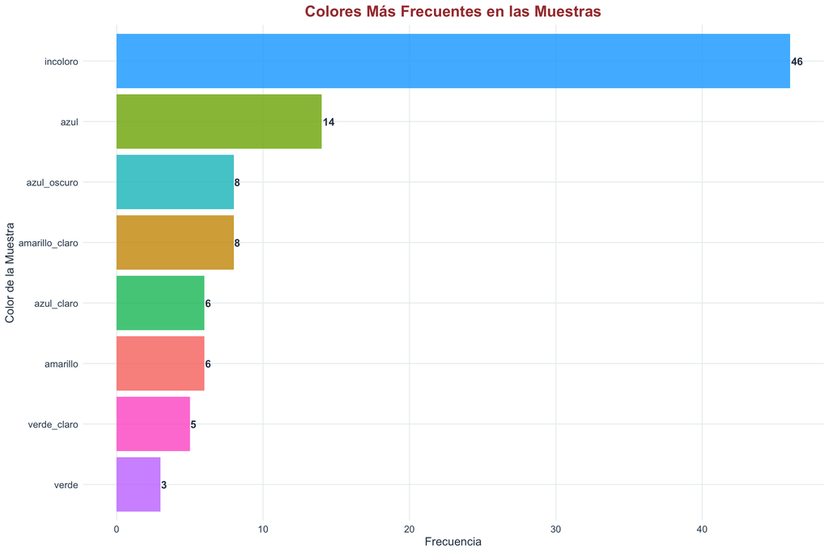

```r
# Cargar librerías adicionales para visualización
library(gridExtra)

# Gráfico de barras para tipos de solución
p1 <- ggplot(datos_limpios, aes(x = tipo_solucion, fill = tipo_solucion)) +
    geom_bar(alpha = 0.8) +
    geom_text(stat = 'count', aes(label = after_stat(count)),
              vjust = -0.5, color = "#2c3e50", fontface = "bold") +
    labs(
        title = "Distribución de Experimentos por Tipo de Solución",
        subtitle = "Dataset de Química Industrial - 100 experimentos",
        x = "Tipo de Solución",
        y = "Número de Experimentos"
    ) +
    scale_fill_brewer(type = "qual", palette = "Set2") +
    theme(
        axis.text.x = element_text(angle = 45, hjust = 1, size = 10),
        legend.position = "none",
        plot.title = element_text(hjust = 0.5),
        plot.subtitle = element_text(hjust = 0.5)
    )

# Gráfico de barras para laboratorios
p2 <- ggplot(datos_limpios, aes(x = laboratorio, fill = laboratorio)) +
    geom_bar(alpha = 0.8) +
    geom_text(stat = 'count', aes(label = after_stat(count)),
              vjust = -0.5, color = "#2c3e50", fontface = "bold") +
    labs(
        title = "Distribución por Laboratorio",
        x = "Laboratorio",
        y = "Número de Experimentos"
    ) +
    scale_fill_manual(values = c("#a73c3c", "#2c3e50", "#34495e")) +
    theme(
        legend.position = "none",
        plot.title = element_text(hjust = 0.5)
    )

# Gráfico de colores más frecuentes
colores_frecuentes <- datos_limpios %>%
    count(color, sort = TRUE) %>%
    slice_head(n = 8)

p3 <- ggplot(colores_frecuentes, aes(x = reorder(color, n), y = n, fill = color)) +
    geom_col(alpha = 0.8) +
    geom_text(aes(label = n), hjust = -0.1, color = "#2c3e50", fontface = "bold") +
    coord_flip() +
    labs(
        title = "Colores Más Frecuentes en las Muestras",
        x = "Color de la Muestra",
        y = "Frecuencia"
    ) +
    theme(
        legend.position = "none",
        plot.title = element_text(hjust = 0.5)
    )

# Mostrar gráficos
grid.arrange(p1, p2, ncol = 2)
print(p3)
```

## 5.2 Histogramas para Variables Numéricas Clave

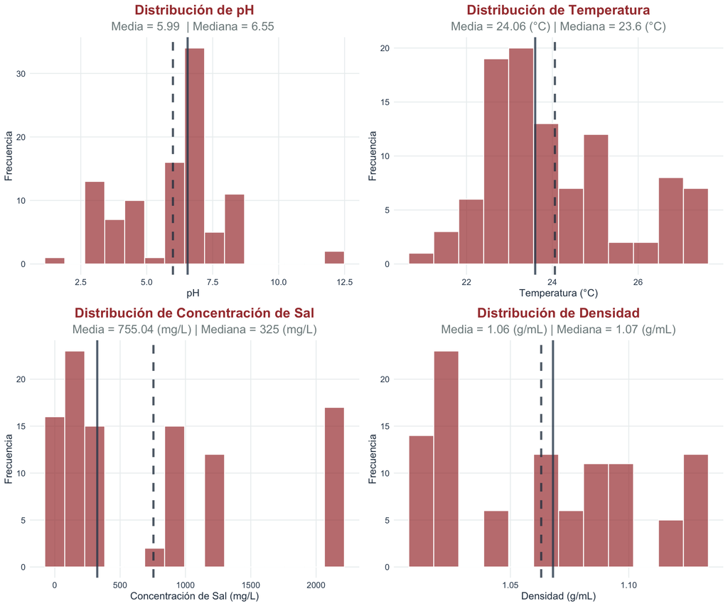

```r
# Función para crear histogramas con estadísticas
crear_histograma <- function(data, variable, titulo, unidad = "", bins = 20) {
    media <- mean(data[[variable]], na.rm = TRUE)
    mediana <- median(data[[variable]], na.rm = TRUE)

    ggplot(data, aes_string(x = variable)) +
        geom_histogram(bins = bins, fill = "#a73c3c", alpha = 0.7, color = "white") +
        geom_vline(aes(xintercept = media), color = "#2c3e50",
                   linetype = "dashed", size = 1.2, alpha = 0.8) +
        geom_vline(aes(xintercept = mediana), color = "#34495e",
                   linetype = "solid", size = 1.2, alpha = 0.8) +
        labs(
            title = paste("Distribución de", titulo),
            subtitle = paste("Media =", round(media, 2), unidad,
                           "| Mediana =", round(mediana, 2), unidad),
            x = paste(titulo, unidad),
            y = "Frecuencia"
        ) +
        theme(
            plot.title = element_text(hjust = 0.5),
            plot.subtitle = element_text(hjust = 0.5, color = "#7f8c8d")
        )
}

# Crear histogramas para variables clave
h1 <- crear_histograma(datos_limpios, "ph", "pH", "", 15)
h2 <- crear_histograma(datos_limpios, "temperatura_C", "Temperatura", "(°C)", 12)
h3 <- crear_histograma(datos_limpios, "concentracion_sal_mg_L", "Concentración de Sal", "(mg/L)", 15)
h4 <- crear_histograma(datos_limpios, "densidad_g_mL", "Densidad", "(g/mL)", 12)

# Mostrar histogramas
grid.arrange(h1, h2, h3, h4, ncol = 2)
```

## 5.3 Boxplots para Detectar Outliers y Comparar Grupos

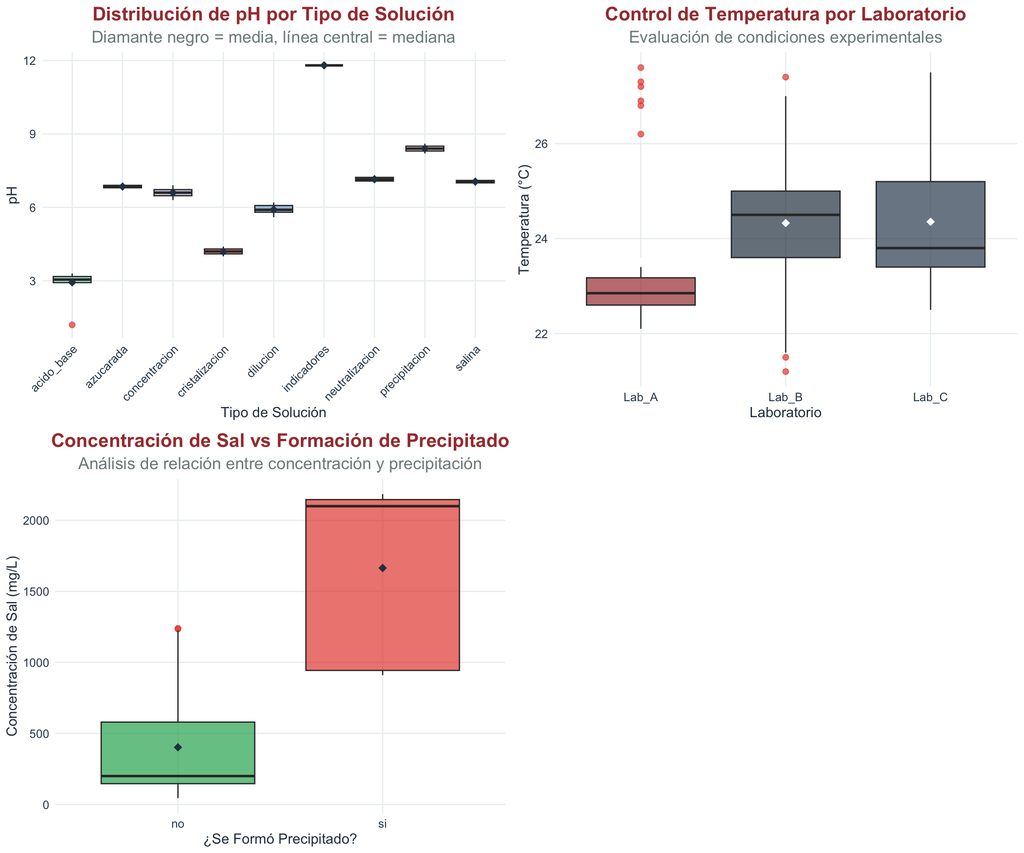

```r
# Boxplot de pH por tipo de solución
b1 <- ggplot(datos_limpios, aes(x = tipo_solucion, y = ph, fill = tipo_solucion)) +
    geom_boxplot(alpha = 0.7, outlier.color = "#e74c3c", outlier.size = 2) +
    stat_summary(fun = mean, geom = "point", shape = 18, size = 3, color = "#2c3e50") +
    labs(
        title = "Distribución de pH por Tipo de Solución",
        subtitle = "Diamante negro = media, línea central = mediana",
        x = "Tipo de Solución",
        y = "pH"
    ) +
    scale_fill_brewer(type = "qual", palette = "Set3") +
    theme(
        axis.text.x = element_text(angle = 45, hjust = 1),
        legend.position = "none",
        plot.title = element_text(hjust = 0.5),
        plot.subtitle = element_text(hjust = 0.5, color = "#7f8c8d")
    )

# Boxplot de temperatura por laboratorio
b2 <- ggplot(datos_limpios, aes(x = laboratorio, y = temperatura_C, fill = laboratorio)) +
    geom_boxplot(alpha = 0.7, outlier.color = "#e74c3c", outlier.size = 2) +
    stat_summary(fun = mean, geom = "point", shape = 18, size = 3, color = "white") +
    labs(
        title = "Control de Temperatura por Laboratorio",
        subtitle = "Evaluación de condiciones experimentales",
        x = "Laboratorio",
        y = "Temperatura (°C)"
    ) +
    scale_fill_manual(values = c("Lab_A" = "#a73c3c", "Lab_B" = "#2c3e50", "Lab_C" = "#34495e")) +
    theme(
        legend.position = "none",
        plot.title = element_text(hjust = 0.5),
        plot.subtitle = element_text(hjust = 0.5, color = "#7f8c8d")
    )

# Boxplot de concentración de sal por precipitación (CORREGIDO)
b3 <- datos_limpios %>%
    filter(!is.na(precipitado_formado) & precipitado_formado != "") %>%  # Filtrar NA y valores vacíos
    ggplot(aes(x = precipitado_formado, y = concentracion_sal_mg_L,
               fill = precipitado_formado)) +
    geom_boxplot(alpha = 0.7, outlier.color = "#e74c3c", outlier.size = 2) +
    stat_summary(fun = mean, geom = "point", shape = 18, size = 3, color = "#2c3e50") +
    labs(
        title = "Concentración de Sal vs Formación de Precipitado",
        subtitle = "Análisis de relación entre concentración y precipitación",
        x = "¿Se Formó Precipitado?",
        y = "Concentración de Sal (mg/L)"
    ) +
    scale_fill_manual(values = c("no" = "#27ae60", "si" = "#e74c3c")) +
    theme(
        legend.position = "none",
        plot.title = element_text(hjust = 0.5),
        plot.subtitle = element_text(hjust = 0.5, color = "#7f8c8d")
    )

# Mostrar boxplots
grid.arrange(b1, b2, b3, ncol = 2)
```

🧪 Interpretación de Visualizaciones Químicas

**Analice los gráficos anteriores y responda:**

1. **Histograma de pH:** ¿Qué tipo de distribución observa? ¿Es simétrica o asimétrica?
2. **Boxplot pH vs Tipo:** ¿Qué tipos de solución tienen los rangos de pH más estrechos/amplios?
3. **Control de temperatura:** ¿Qué laboratorio mantiene mejor control de temperatura?
4. **Concentración vs Precipitado:** ¿Existe una relación clara? ¿A partir de qué concentración se forma precipitado?

# 6 Paso 6: Análisis Bivariado - Relaciones entre Variables

## 6.1 Matriz de Correlación para Variables Numéricas

```r
# Seleccionar variables numéricas para correlación
vars_numericas <- datos_limpios %>%
    select(ph, temperatura_C, concentracion_sal_mg_L, concentracion_azucar_g_L,
           volumen_muestra_mL, masa_soluto_g, densidad_g_mL, tiempo_reaccion_min) %>%
    select_if(is.numeric)

# Calcular matriz de correlación
matriz_corr <- cor(vars_numericas, use = "complete.obs")

# Visualizar con corrplot
corrplot(matriz_corr,
         method = "color",
         type = "upper",
         order = "hclust",
         tl.col = "#2c3e50",
         tl.srt = 45,
         tl.cex = 0.8,
         col = colorRampPalette(c("#e74c3c", "white", "#2c3e50"))(100),
         addCoef.col = "black",
         number.cex = 0.7,
         title = "Matriz de Correlación - Variables Químicas",
         mar = c(0,0,2,0))

# Mostrar correlaciones más fuertes
cat("\n=== CORRELACIONES MÁS FUERTES (|r| > 0.7) ===\n")
```

```
#>
#> === CORRELACIONES MÁS FUERTES (|r| > 0.7) ===
```

```r
for (i in 1:(ncol(matriz_corr)-1)) {
    for (j in (i+1):ncol(matriz_corr)) {
        corr_val <- matriz_corr[i, j]
        if (abs(corr_val) > 0.7) {
            cat(colnames(matriz_corr)[i], "vs", colnames(matriz_corr)[j],
                ": r =", round(corr_val, 3), "\n")
        }
    }
}
```

```
#> temperatura_C vs concentracion_sal_mg_L : r = 0.876
#> temperatura_C vs densidad_g_mL : r = 0.857
#> temperatura_C vs tiempo_reaccion_min : r = 0.771
#> concentracion_sal_mg_L vs densidad_g_mL : r = 0.841
#> concentracion_sal_mg_L vs tiempo_reaccion_min : r = 0.815
#> concentracion_azucar_g_L vs masa_soluto_g : r = 0.845
```

[figure not shown]

## 6.2 Gráficos de Dispersión para Relaciones Clave

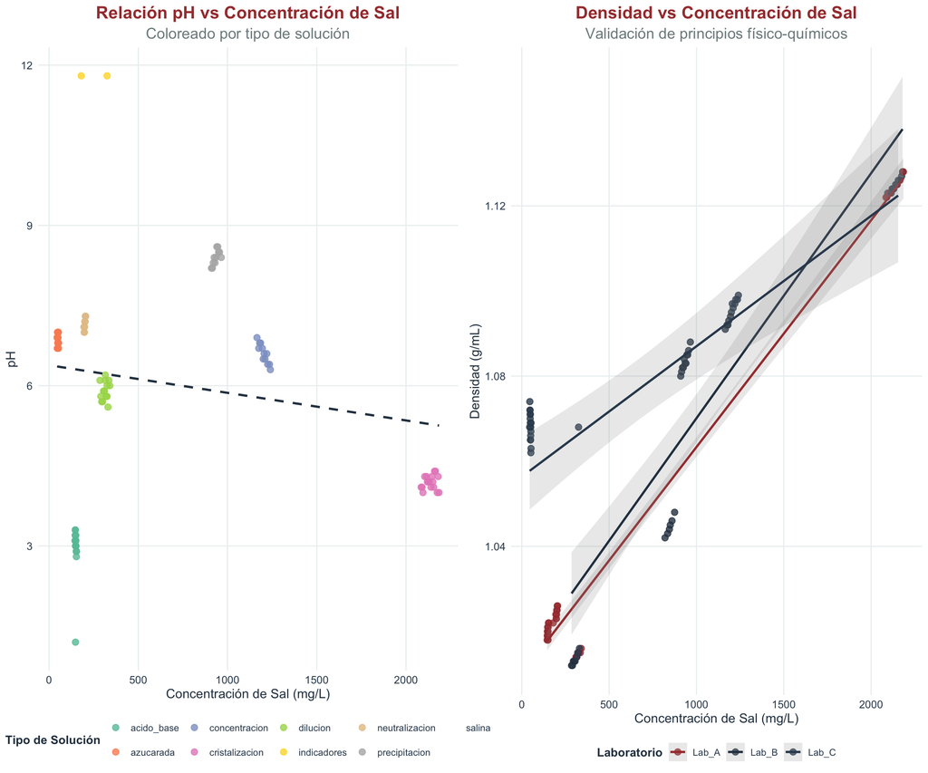

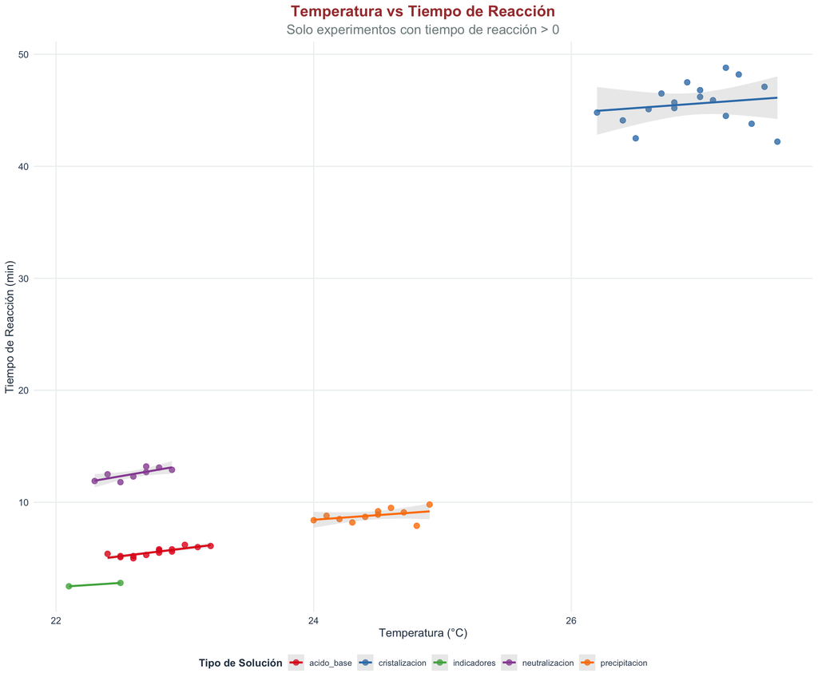

```r
# Gráfico de dispersión: pH vs Concentración de sal (coloreado por tipo)
s1 <- ggplot(datos_limpios, aes(x = concentracion_sal_mg_L, y = ph, color = tipo_solucion)) +
    geom_point(size = 2.5, alpha = 0.8) +
    geom_smooth(method = "lm", se = FALSE, color = "#2c3e50", linetype = "dashed") +
    labs(
        title = "Relación pH vs Concentración de Sal",
        subtitle = "Coloreado por tipo de solución",
        x = "Concentración de Sal (mg/L)",
        y = "pH",
        color = "Tipo de Solución"
    ) +
    scale_color_brewer(type = "qual", palette = "Set2") +
    theme(
        plot.title = element_text(hjust = 0.5),
        plot.subtitle = element_text(hjust = 0.5, color = "#7f8c8d"),
        legend.position = "bottom"
    )

# Gráfico de dispersión: Densidad vs Concentración de sal
s2 <- ggplot(datos_limpios, aes(x = concentracion_sal_mg_L, y = densidad_g_mL,
                               color = laboratorio)) +
    geom_point(size = 2.5, alpha = 0.8) +
    geom_smooth(method = "lm", se = TRUE, alpha = 0.2) +
    labs(
        title = "Densidad vs Concentración de Sal",
        subtitle = "Validación de principios físico-químicos",
        x = "Concentración de Sal (mg/L)",
        y = "Densidad (g/mL)",
        color = "Laboratorio"
    ) +
    scale_color_manual(values = c("#a73c3c", "#2c3e50", "#34495e")) +
    theme(
        plot.title = element_text(hjust = 0.5),
        plot.subtitle = element_text(hjust = 0.5, color = "#7f8c8d"),
        legend.position = "bottom"
    )

# Gráfico de dispersión: Temperatura vs Tiempo de reacción
s3 <- datos_limpios %>%
    filter(tiempo_reaccion_min > 0) %>%  # Solo reacciones que toman tiempo
    ggplot(aes(x = temperatura_C, y = tiempo_reaccion_min, color = tipo_solucion)) +
    geom_point(size = 2.5, alpha = 0.8) +
    geom_smooth(method = "lm", se = TRUE, alpha = 0.2) +
    labs(
        title = "Temperatura vs Tiempo de Reacción",
        subtitle = "Solo experimentos con tiempo de reacción > 0",
        x = "Temperatura (°C)",
        y = "Tiempo de Reacción (min)",
        color = "Tipo de Solución"
    ) +
    scale_color_brewer(type = "qual", palette = "Set1") +
    theme(
        plot.title = element_text(hjust = 0.5),
        plot.subtitle = element_text(hjust = 0.5, color = "#7f8c8d"),
        legend.position = "bottom"
    )

# Mostrar gráficos de dispersión
grid.arrange(s1, s2, ncol = 2)
print(s3)
```

# 7 Paso 7: Implementación de Estructuras de Control

**🔧 Estructuras de Control en R:** Ahora implementaremos condicionales y bucles para automatizar el análisis de datos químicos. Esto nos permitirá procesar múltiples variables y generar reportes automáticos.

## 7.1 Uso de if/else para Clasificación Química

```r
# Función para clasificar acidez basada en pH
clasificar_acidez <- function(ph_valor) {
    if (is.na(ph_valor)) {
        return("Sin datos")
    } else if (ph_valor < 3) {
        return("Muy ácido")
    } else if (ph_valor < 6) {
        return("Ácido")
    } else if (ph_valor < 8) {
        return("Neutro")
    } else if (ph_valor < 11) {
        return("Básico")
    } else {
        return("Muy básico")
    }
}

# Aplicar clasificación a todo el dataset
datos_limpios$clasificacion_ph <- sapply(datos_limpios$ph, clasificar_acidez)

# Mostrar tabla de clasificación
tabla_acidez <- table(datos_limpios$clasificacion_ph)
cat("=== CLASIFICACIÓN DE ACIDEZ ===\n")
```

```
#> === CLASIFICACIÓN DE ACIDEZ ===
```

```r
for (i in 1:length(tabla_acidez)) {
    porcentaje <- round((tabla_acidez[i] / sum(tabla_acidez)) * 100, 1)
    cat(names(tabla_acidez)[i], ":", tabla_acidez[i], "muestras (", porcentaje, "%)\n")
}
```

```
#> Ácido : 35 muestras ( 35 %)
#> Básico : 11 muestras ( 11 %)
#> Muy ácido : 4 muestras ( 4 %)
#> Muy básico : 2 muestras ( 2 %)
#> Neutro : 48 muestras ( 48 %)
```

```r
# Función para evaluar calidad de concentración
evaluar_concentracion <- function(concentracion, tipo_solucion) {
    if (is.na(concentracion)) return("Sin datos")

    if (tipo_solucion == "concentracion") {
        if (concentracion > 1000) return("Alta concentración")
        else return("Concentración insuficiente")
    } else if (tipo_solucion == "dilucion") {
        if (concentracion < 400) return("Dilución adecuada")
        else return("Requiere más dilución")
    } else if (tipo_solucion == "salina") {
        if (concentracion >= 800 && concentracion <= 900) return("Concentración óptima")
        else return("Fuera del rango óptimo")
    } else {
        return("Concentración normal")
    }
}

# Aplicar evaluación de concentración
datos_limpios$evaluacion_conc <- mapply(evaluar_concentracion,
                                      datos_limpios$concentracion_sal_mg_L,
                                      datos_limpios$tipo_solucion)

# Mostrar resultados
cat("\n=== EVALUACIÓN DE CONCENTRACIONES ===\n")
```

```
#>
#> === EVALUACIÓN DE CONCENTRACIONES ===
```

```r
tabla_eval_conc <- table(datos_limpios$evaluacion_conc)
for (i in 1:length(tabla_eval_conc)) {
    cat(names(tabla_eval_conc)[i], ":", tabla_eval_conc[i], "muestras\n")
}
```

```
#> Alta concentración : 12 muestras
#> Concentración normal : 68 muestras
#> Concentración óptima : 6 muestras
#> Dilución adecuada : 14 muestras
```

## 7.2 Bucles for para Análisis Automatizado por Grupos

```r
# Análisis automatizado por tipo de solución usando bucles for
tipos_solucion <- unique(datos_limpios$tipo_solucion)
resultados_por_tipo <- data.frame()

cat("=== ANÁLISIS AUTOMATIZADO POR TIPO DE SOLUCIÓN ===\n\n")
```

```
#> === ANÁLISIS AUTOMATIZADO POR TIPO DE SOLUCIÓN ===
```

```r
for (tipo in tipos_solucion) {
    cat("Analizando tipo:", tipo, "\n")
    cat(paste(rep("=", nchar(tipo) + 15), collapse = ""), "\n")

    # Filtrar datos para este tipo
    datos_tipo <- datos_limpios[datos_limpios$tipo_solucion == tipo, ]
    n_muestras <- nrow(datos_tipo)

    # Calcular estadísticas
    ph_promedio <- mean(datos_tipo$ph, na.rm = TRUE)
    ph_desv <- sd(datos_tipo$ph, na.rm = TRUE)
    temp_promedio <- mean(datos_tipo$temperatura_C, na.rm = TRUE)
    conc_sal_max <- max(datos_tipo$concentracion_sal_mg_L, na.rm = TRUE)

    # Calcular proporción de precipitados
    precipitados <- sum(datos_tipo$precipitado_formado == "si", na.rm = TRUE)
    prop_precipitados <- round((precipitados / n_muestras) * 100, 1)

    # Mostrar resultados
    cat("Número de muestras:", n_muestras, "\n")
    cat("pH promedio:", round(ph_promedio, 2), "±", round(ph_desv, 2), "\n")
    cat("Temperatura promedio:", round(temp_promedio, 1), "°C\n")
    cat("Concentración máxima de sal:", conc_sal_max, "mg/L\n")
    cat("Precipitados formados:", precipitados, "(", prop_precipitados, "%)\n")

    # Determinar características especiales
    if (ph_promedio < 4) {
        cat("Característica: Soluciones muy ácidas\n")
    } else if (ph_promedio > 8) {
        cat("Característica: Soluciones básicas\n")
    } else {
        cat("Característica: Soluciones neutras/ligeramente ácidas\n")
    }

    # Guardar en tabla resumen
    fila_resultado <- data.frame(
        Tipo = tipo,
        N_Muestras = n_muestras,
        pH_Promedio = round(ph_promedio, 2),
        pH_DesviacionStd = round(ph_desv, 2),
        Temp_Promedio = round(temp_promedio, 1),
        Conc_Sal_Max = conc_sal_max,
        Precipitados_Pct = prop_precipitados
    )

    resultados_por_tipo <- rbind(resultados_por_tipo, fila_resultado)
    cat("\n")
}
```

```
#> Analizando tipo: acido_base
#> =========================
#> Número de muestras: 14
#> pH promedio: 2.94 ± 0.52
#> Temperatura promedio: 22.8 °C
#> Concentración máxima de sal: 154 mg/L
#> Precipitados formados: 0 ( 0 %)
#> Característica: Soluciones muy ácidas
#>
#> Analizando tipo: salina
#> =====================
#> Número de muestras: 6
#> pH promedio: 7.05 ± 0.1
#> Temperatura promedio: 21.7 °C
#> Concentración máxima de sal: 875 mg/L
#> Precipitados formados: 0 ( 0 %)
#> Característica: Soluciones neutras/ligeramente ácidas
#>
#> Analizando tipo: azucarada
#> ========================
#> Número de muestras: 16
#> pH promedio: 6.85 ± 0.1
#> Temperatura promedio: 23.4 °C
#> Concentración máxima de sal: 53 mg/L
#> Precipitados formados: 0 ( 0 %)
#> Característica: Soluciones neutras/ligeramente ácidas
#>
#> Analizando tipo: precipitacion
#> ============================
#> Número de muestras: 11
#> pH promedio: 8.4 ± 0.14
#> Temperatura promedio: 24.5 °C
#> Concentración máxima de sal: 965 mg/L
#> Precipitados formados: 11 ( 100 %)
#> Característica: Soluciones básicas
#>
#> Analizando tipo: neutralizacion
#> =============================
#> Número de muestras: 8
#> pH promedio: 7.15 ± 0.12
```

[output cut: 25 more lines]

```
#> Número de muestras: 17
#> pH promedio: 4.19 ± 0.13
#> Temperatura promedio: 27 °C
#> Concentración máxima de sal: 2185 mg/L
#> Precipitados formados: 17 ( 100 %)
#> Característica: Soluciones neutras/ligeramente ácidas
#>
#> Analizando tipo: indicadores
#> ==========================
#> Número de muestras: 2
#> pH promedio: 11.8 ± 0
#> Temperatura promedio: 22.3 °C
#> Concentración máxima de sal: 325 mg/L
#> Precipitados formados: 0 ( 0 %)
#> Característica: Soluciones básicas
```

```r
# Mostrar tabla resumen
kable(resultados_por_tipo,
      caption = "Resumen Automático por Tipo de Solución",
      align = "lcccccc")
```

Resumen Automático por Tipo de Solución

| Tipo | N_Muestras | pH_Promedio | pH_DesviacionStd | Temp_Promedio | Conc_Sal_Max | Precipitados_Pct |
| --- | --- | --- | --- | --- | --- | --- |
| acido_base | 14 | 2.94 | 0.52 | 22.8 | 154 | 0 |
| salina | 6 | 7.05 | 0.10 | 21.7 | 875 | 0 |
| azucarada | 16 | 6.85 | 0.10 | 23.4 | 53 | 0 |
| precipitacion | 11 | 8.40 | 0.14 | 24.5 | 965 | 100 |
| neutralizacion | 8 | 7.15 | 0.12 | 22.6 | 205 | 0 |
| concentracion | 12 | 6.60 | 0.19 | 25.1 | 1240 | 0 |
| dilucion | 14 | 5.91 | 0.18 | 23.4 | 340 | 0 |
| cristalizacion | 17 | 4.19 | 0.13 | 27.0 | 2185 | 100 |
| indicadores | 2 | 11.80 | 0.00 | 22.3 | 325 | 0 |

## 7.3 Bucle while para Control de Calidad Iterativo

```r
# Control de calidad iterativo para detectar outliers extremos en pH
datos_control <- datos_limpios
outliers_encontrados <- TRUE
iteracion <- 0
max_iteraciones <- 3
datos_removidos <- data.frame()

cat("=== CONTROL DE CALIDAD ITERATIVO ===\n")
```

```
#> === CONTROL DE CALIDAD ITERATIVO ===
```

```r
cat("Criterio: Outliers extremos en pH (> 3 × IQR)\n\n")
```

```
#> Criterio: Outliers extremos en pH (> 3 × IQR)
```

```r
while (outliers_encontrados && iteracion < max_iteraciones) {
    iteracion <- iteracion + 1
    cat("Iteración", iteracion, ":\n")

    # Calcular límites IQR para pH
    Q1_ph <- quantile(datos_control$ph, 0.25, na.rm = TRUE)
    Q3_ph <- quantile(datos_control$ph, 0.75, na.rm = TRUE)
    IQR_ph <- Q3_ph - Q1_ph

    # Límites extremos (3 × IQR en lugar de 1.5 × IQR)
    limite_inf <- Q1_ph - 3 * IQR_ph
    limite_sup <- Q3_ph + 3 * IQR_ph

    cat("  Límites de pH: [", round(limite_inf, 2), ",", round(limite_sup, 2), "]\n")

    # Identificar outliers extremos
    outliers_indices <- which(datos_control$ph < limite_inf | datos_control$ph > limite_sup)

    if (length(outliers_indices) == 0) {
        outliers_encontrados <- FALSE
        cat("  No se encontraron más outliers extremos\n")
    } else {
        # Mostrar outliers encontrados
        cat("  Outliers extremos encontrados:", length(outliers_indices), "\n")
        for (idx in outliers_indices) {
            cat("    Experimento", datos_control$experimento_id[idx],
                "- pH:", datos_control$ph[idx],
                "- Tipo:", datos_control$tipo_solucion[idx], "\n")
        }

        # Guardar datos removidos para auditoría
        datos_removidos <- rbind(datos_removidos, datos_control[outliers_indices, ])

        # Remover outliers extremos
        datos_control <- datos_control[-outliers_indices, ]
        cat("  Datos restantes:", nrow(datos_control), "de", nrow(datos_limpios), "originales\n")
    }
    cat("\n")
}
```

```
#> Iteración 1 :
#>   Límites de pH: [ -3.9 , 15.18 ]
#>   No se encontraron más outliers extremos
```

```r
cat("Proceso completado en", iteracion, "iteraciones\n")
```

```
#> Proceso completado en 1 iteraciones
```

```r
cat("Total de datos removidos:", nrow(datos_removidos), "\n")
```

```
#> Total de datos removidos: 0
```

```r
cat("Porcentaje de datos conservados:",
    round((nrow(datos_control) / nrow(datos_limpios)) * 100, 1), "%\n")
```

```
#> Porcentaje de datos conservados: 100 %
```

```r
# Mostrar estadísticas antes y después
cat("\n=== COMPARACIÓN ANTES Y DESPUÉS DEL CONTROL ===\n")
```

```
#>
#> === COMPARACIÓN ANTES Y DESPUÉS DEL CONTROL ===
```

```r
cat("pH promedio original:", round(mean(datos_limpios$ph, na.rm = TRUE), 3), "\n")
```

```
#> pH promedio original: 5.993
```

```r
cat("pH promedio post-control:", round(mean(datos_control$ph, na.rm = TRUE), 3), "\n")
```

```
#> pH promedio post-control: 5.993
```

```r
cat("Desviación estándar original:", round(sd(datos_limpios$ph, na.rm = TRUE), 3), "\n")
```

```
#> Desviación estándar original: 1.897
```

```r
cat("Desviación estándar post-control:", round(sd(datos_control$ph, na.rm = TRUE), 3), "\n")
```

```
#> Desviación estándar post-control: 1.897
```

Actividad Práctica: Estructuras de Control

**Implemente las siguientes estructuras de control:**

1. **If/else:** Cree una función que clasifique la densidad como “Baja”, “Normal” o “Alta” basándose en los cuartiles.
2. **For loop:** Genere un reporte automático de temperaturas por laboratorio, calculando media, mediana y rango para cada uno.
3. **While loop:** Implemente un algoritmo que normalice las concentraciones de azúcar eliminando iterativamente valores que estén fuera de 2 desviaciones estándar.